# W5-Kazalnak-Valley

Jakob Grøhn Damgaard

3/5/2021

## Task 1: Analyze burial mound health

A number of factors can negatively affect cultural heritage, from natural post-depositional processes, such as chemical and mechanical weathering, to animal-activity and human-inflicted damage, which can be either direct (excavation, looting) or indirect (development, agricultural activities, transport). In order to understand the anthropic impacts on cultural heritage, archaeologists routinely assess the condition of different types of cultural remains. In the burial mounds dataset, the Condition column contains a professional judgment of monument health recorded on a Likert-scale from 1 to 5, where 1 means the feature is in pristine state, while 5 means it is extinct or nearly so. The ‘Robbed’ column, specifies via a binary value of 1/0 (corresponding to Yes/No), whether looting was detected on site. The LandUse column contains the surrounding land use, which can also relate to the condition.

Design a study to evaluate direct or indirect impacts on burial mounds. You can use the provided datasets to extract a number of possible variables for this purpose:

- location-related variables such as elevation, aspect, slope (are mounds on steep slopes or in lower elevations disproportionately more vulnerable? )
- mound size (are larger mounds disproportionately affected by looters?)
- mound proximity to roads, rivers, nearest settlement boundary or center, regional capital boundary or center (do - looters rob mounds that are closer to the settlements? are mounds near large urban centers disproportionally damaged/looted? are mounds in the vicinity of the Koprinka reservoir - the large dam in the middle of the valley, see kaz_lakes.shp - more damaged?)
- landuse around the mound (are mounds in agricultural fields more prone to damage than mounds in the forests?)
- Take one or more questions and elaborate it into a study using spatial operations on vector and raster.

# My task:

## Analysing the impact of the slope of the landscape on the health of burial mounds in Kazalnak Valley

In this short study, I wish to investigate whether the slope of the landscape under and around a burial mound has a impact on the deterioration of the mound. Landscapes with severe slopes are more exposed to wind and flowing water after rain and mounds located in such terrain may, hence, deteriorate faster.

## Loading the data

Data:  
- Aster.tif: A digital elevation map of the Kazalnak Valley  
- KAZ_mounds.shp: A shapefile containing the GPS coordinates of the locations of the marked burial mounds  
- KAT_mdata.csv: Meta-data on the burial mounds containing e.g. information on health status

```r
# Loading data files
kaz_elevation_map <- raster("data/aster.tif")
mound_coordinates <-  st_read("data/KAZ_mounds.shp")
mound_attributes <- read_csv("data/KAZ_mdata.csv")
# Checking whether the shapefile and raster file are aligned with the same CRS
st_crs(mound_coordinates)
crs(kaz_elevation_map)
# The CRS for both files is WGS84/UTM 35N
```

## Fixing elevation map

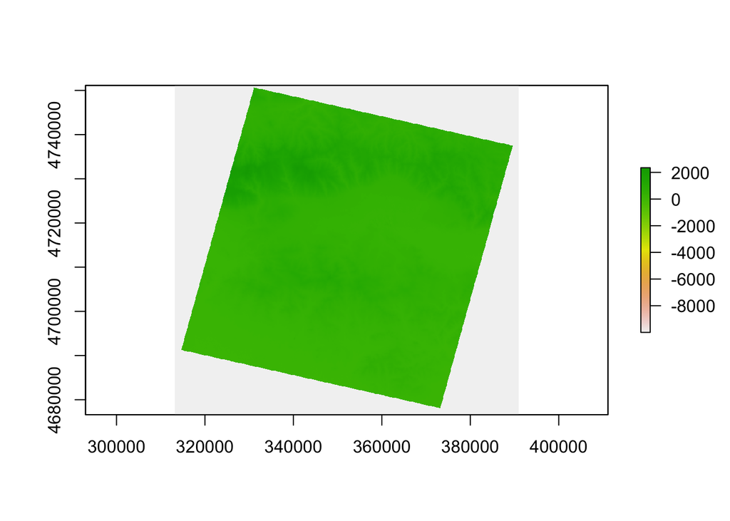

```r
# Checking skewed data
plot(kaz_elevation_map)
```

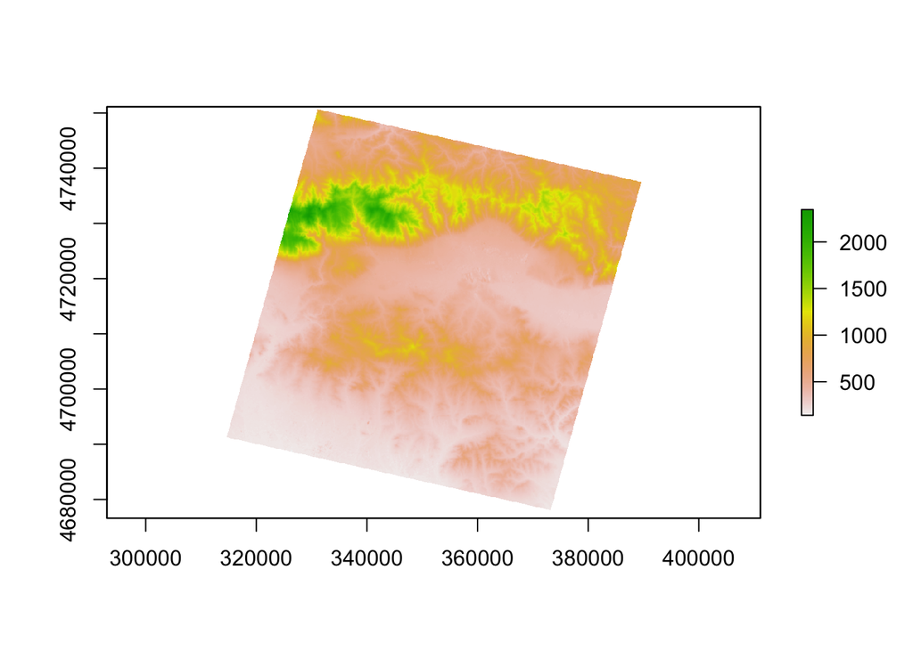

```r
# Changing negative values to NAs
rclmat <- cbind(-10000,-1, NA)
kaz_elevation_map <- reclassify(kaz_elevation_map, rcl = rclmat)

# Checking if fix worked
plot(kaz_elevation_map)
```

## Combining attributes and coordinate data

Joining the attribute data file with the shapefile

```r
# Renaming ID column in the coordinate data frame:
colnames(mound_coordinates)[2] <- "MoundID"

# Joining data frame using merge()
mound_data <- merge(mound_coordinates, mound_attributes, by = "MoundID")
```

## Extracting ground slope attribute

The ground slopes around the mounds needs to be manually calculated from the avaliable data

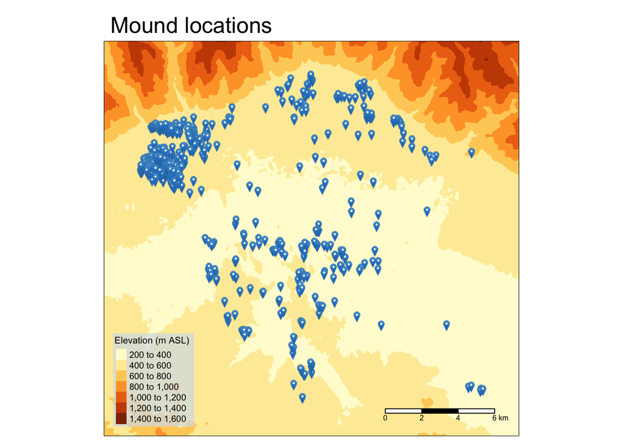

```r
# Crop the raster to only include the bounding box that encapsulates all mounds
# Creating bounding box with a border
mound_bbox_with_bird <-  as(extent(352481.3-2000, 371282.4+2000, 4712325-2000, 4730029+2000), 'SpatialPolygons')
# Cropping the raster
kaz_elevation_map_cropped <- crop(kaz_elevation_map, mound_bbox_with_bird)

# Mapping the mound locations on the raster to see if everything works
tm_shape(kaz_elevation_map_cropped)+
  tm_raster(title = "Elevation (m ASL)")+
  tm_shape(mound_data)+
  tm_markers(size = 0.1)+
  tm_scale_bar()+
  tm_layout(main.title = "Mound locations",
            legend.position = c("left","bottom"),
            legend.bg.color = "#D6E0EA",
            legend.bg.alpha = 0.7,
            legend.text.size = 0.6,
            legend.title.size = 0.75)
```

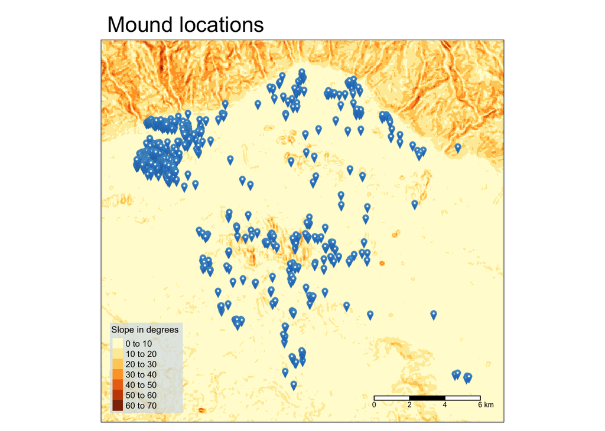

```r
# Calculating the slope of each cell
slope_raster = terrain(kaz_elevation_map_cropped, opt='slope', unit='degrees', neighbors=8)

# Mapping the mound locations on the slope raster
tm_shape(slope_raster)+
  tm_raster(title = "Slope in degrees")+
  tm_shape(mound_data)+
  tm_markers(size = 0.1)+
  tm_scale_bar()+
  tm_layout(main.title = "Mound locations",
            legend.position = c("left","bottom"),
            legend.bg.color = "#D6E0EA",
            legend.bg.alpha = 0.7,
            legend.text.size = 0.6,
            legend.title.size = 0.75)
```

```r
# Calculating the average slope around each mound coordinate using buffers with a radius of 1 meter
mound_data$slope <- raster::extract(slope_raster, mound_data, buffer = 1, fun = mean)

# Removing mounds with NA slope values
mound_data <- subset(mound_data, !is.na(mound_data$slope))
```

It would have been nice to average the slope across a larger area in order to capture a more robust measure of the landscape slope. Even better would be to weight the buffer according to mound height in order to average slope across more land area for larger mounds and less land area for tiny mounds. However, as buffers cannot overlap and since some mounds are located extremely close to each other, this would result in a lot of NAs.

## Plotting the health of slope on burial mound health

In order to visually inspect whether an increase in ground slope systematically leads to more deterioration, the health scores (Likert scale) of the mounds are plotted against the calculated slope scores.

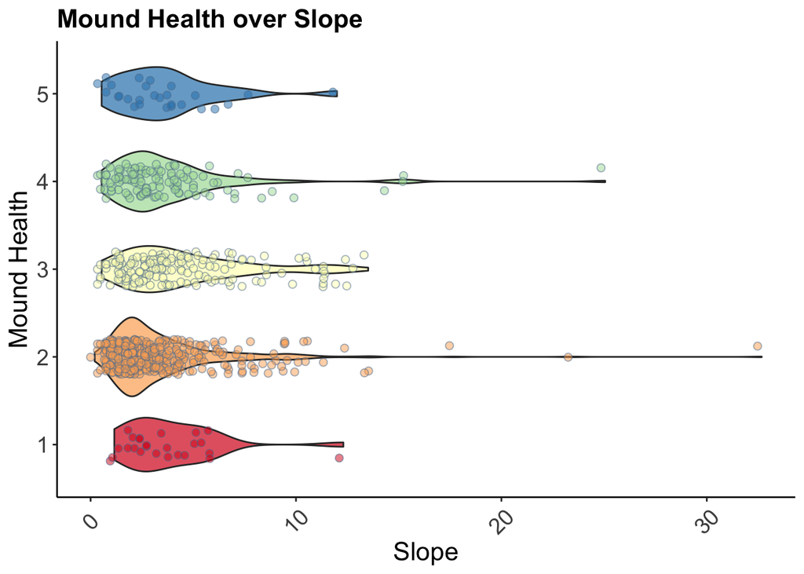

```r
# Setting personalised theme because I love playing with the aesthetics
my_theme = theme(
text = element_text(size = 10),
axis.title.x = element_text(size = 16),
axis.title.y = element_text(size = 16),
axis.text = element_text(size = 14),
axis.text.x = element_text(angle = 45, vjust = 0.5),
plot.title = element_text(lineheight=.8, face="bold", size = 16),
panel.border = element_blank(),
panel.grid.minor = element_blank(),
panel.grid.major = element_blank(),
axis.line.x = element_line(colour = 'black', size=0.5, linetype='solid'),
axis.line.y = element_line(colour = 'black', size=0.5, linetype='solid'))

# Setting the condition data as factors
mound_data$Condition <- as.factor(mound_data$Condition)

# Plotting the health of the mounds against the average slope of the landscape around the mounds
ggplot(data = mound_data, aes(x = slope, y= Condition, fill = Condition))+
  geom_violin(alpha = .7, position = position_nudge(x = .2, y = 0))+
  geom_point(size=2, colour = "#5F7E9C", shape = 21 , position = position_jitter(height = 0.2), alpha = 0.5)+
  theme_classic()+ # White background
  labs(title = "Mound Health over Slope", x = "Slope", y = "Mound Health")+
  scale_color_brewer(palette = "Spectral") +
  scale_fill_brewer(palette = "Spectral") +
  theme(legend.position="none") +
  my_theme
```

At first glance there does not seem to be a noteworthy effect of ground slope on the health of the mounds. In other words, there is no indication that a mound located on more sloped ground leads to more deterioration and wear. However, interpreting a plot containing a continual variable on the x-axis an ordinal variable on the y-axis is difficult and should not alone form the basis of a quantitative analysis. Instead we can run a ordinal logistic regression on the data to quanitfy the effects of ground slope.

## Ordinal logistic regression

```r
# Fitting the ordinal logistic regression using the polr() function from the MASS package
ordinal_log_reg_slope <- MASS::polr(Condition ~ slope, data = mound_data, Hess=TRUE)

# Showing model summmry
summary(ordinal_log_reg_slope)
```

```
## Call:
## MASS::polr(formula = Condition ~ slope, data = mound_data, Hess = TRUE)
##
## Coefficients:
##         Value Std. Error t value
## slope 0.04434    0.02281   1.943
##
## Intercepts:
##     Value    Std. Error t value
## 1|2  -3.1050   0.2177   -14.2614
## 2|3   0.4068   0.1160     3.5060
## 3|4   1.5190   0.1309    11.6035
## 4|5   3.3545   0.2164    15.5006
##
## Residual Deviance: 1664.202
## AIC: 1674.202
```

```r
# Extracting coefficients table
coef_table <- coef(summary(ordinal_log_reg_slope))

# Obtaining the odds ratio (exponentiation the estimate)
OR = exp(coef(ordinal_log_reg_slope))
OR
```

```
##    slope
## 1.045335
```

```r
# Obtaining the 95% confidence intervals for the odds ratio
ci <- confint(ordinal_log_reg_slope)
OR_ci <- exp(ci) # Exponentiating the estimate confidence interval to get the odds ratio confidence interval
OR_ci # If 1 is included in the interval, the effect is not 'statistically significant'
```

```
##     2.5 %    97.5 %
## 0.9990082 1.0927974
```